# casestudy_eda

## Case Study: Qualität von Rotwein (Peter Müller)

Ziel der Analyse ist es, die wichtigsten Faktoren ausfindig zu machen, die zu einer guten Rotweinqualität führen. Basierend darauf soll ein Entscheidungsalgorithmus entwickelt werden, der Rotweine anhand Ihrer Eigenschaften in Qualitätsgruppen einteilt. Zu Beginn werden die notwendigen libraries und der Datensatz geladen. Dabei werde ich 20% der Daten für den Testdatensatz beiseitehalten. Die Informationen dieser Daten sollen nicht in meine Entscheidungsfindung einfließen.

```python
import pandas as pd
import numpy as np
from summarytools import dfSummary
import seaborn as sns
import matplotlib.pyplot as plt
from sklearn.model_selection import train_test_split, cross_val_score
from sklearn.ensemble import RandomForestClassifier
from imblearn.over_sampling import SMOTE
from sklearn.feature_selection import SelectKBest, mutual_info_classif, f_classif
from sklearn.metrics import f1_score, accuracy_score, precision_score, recall_score
from statsmodels.stats.multicomp import pairwise_tukeyhsd
from scipy.stats import f_oneway
```

```python
# Daten laden
wein = pd.read_csv("winequality-red.csv", sep=";")
# 80 % für den trainings Datensatz, 20% für den Test Datensatz
wein_train, wein_test = train_test_split(wein, test_size=0.2)
```

## Data Cleaning

Zuers verschaffe ich mir einen Überblick über die vorhandenen Merkmale (Features) mit der dfSummary Funktion die mir zugleich einen ersten Einblick in Datenqualität und deskriptive Statistiken bietet. Es stellt sich heraus dass der Datensatz keine fehlende Werte besitzt, jedoch Duplikate die ich entferne. Anschließend überprüfe ich nochmals die Zusammenfassung.

```python
dfSummary(wein_train, is_collapsible = True)
```

**Data Frame Summary** wein_train Dimensions: 1,279 x 12 Duplicates: 155

| No | Variable | Stats / Values | Freqs / (% of Valid) | Graph | Missing |
| --- | --- | --- | --- | --- | --- |
| 1 | **fixed acidity** [float64] | Mean (sd) : 8.3 (1.7) min < med < max: 4.6 < 7.9 < 15.9 IQR (CV) : 2.2 (4.8) | 93 distinct values |  | 0 (0.0%) |
| 2 | **volatile acidity** [float64] | Mean (sd) : 0.5 (0.2) min < med < max: 0.1 < 0.5 < 1.6 IQR (CV) : 0.2 (3.0) | 137 distinct values |  | 0 (0.0%) |
| 3 | **citric acid** [float64] | Mean (sd) : 0.3 (0.2) min < med < max: 0.0 < 0.2 < 0.8 IQR (CV) : 0.3 (1.4) | 77 distinct values |  | 0 (0.0%) |
| 4 | **residual sugar** [float64] | Mean (sd) : 2.6 (1.4) min < med < max: 0.9 < 2.2 < 15.5 IQR (CV) : 0.7 (1.8) | 85 distinct values |  | 0 (0.0%) |
| 5 | **chlorides** [float64] | Mean (sd) : 0.1 (0.0) min < med < max: 0.0 < 0.1 < 0.6 IQR (CV) : 0.0 (1.9) | 143 distinct values |  | 0 (0.0%) |
| 6 | **free sulfur dioxide** [float64] | Mean (sd) : 15.8 (10.6) min < med < max: 1.0 < 13.0 < 72.0 IQR (CV) : 14.0 (1.5) | 60 distinct values |  | 0 (0.0%) |
| 7 | **total sulfur dioxide** [float64] | Mean (sd) : 46.3 (32.4) min < med < max: 6.0 < 38.0 < 289.0 IQR (CV) : 40.0 (1.4) | 141 distinct values |  | 0 (0.0%) |
| 8 | **density** [float64] | Mean (sd) : 1.0 (0.0) min < med < max: 1.0 < 1.0 < 1.0 IQR (CV) : 0.0 (532.2) | 397 distinct values |  | 0 (0.0%) |
| 9 | **pH** [float64] | Mean (sd) : 3.3 (0.2) min < med < max: 2.9 < 3.3 < 4.0 IQR (CV) : 0.2 (21.4) | 87 distinct values |  | 0 (0.0%) |
| 10 | **sulphates** [float64] | Mean (sd) : 0.7 (0.2) min < med < max: 0.4 < 0.6 < 2.0 IQR (CV) : 0.2 (3.9) | 89 distinct values |  | 0 (0.0%) |
| 11 | **alcohol** [float64] | Mean (sd) : 10.4 (1.1) min < med < max: 8.4 < 10.2 < 14.9 IQR (CV) : 1.5 (9.8) | 61 distinct values |  | 0 (0.0%) |
| 12 | **quality** [int64] | 1. 5 2. 6 3. 7 4. 4 5. 8 6. 3 | 548 (42.8%) 508 (39.7%) 154 (12.0%) 45 (3.5%) 15 (1.2%) 9 (0.7%) |  | 0 (0.0%) |

```python
# cl steht für "cleaned"
wein_train_cl = wein_train.drop_duplicates()
dfSummary(wein_train_cl, is_collapsible = True)
```

**Data Frame Summary** wein_train_cl Dimensions: 1,124 x 12 Duplicates: 0

| No | Variable | Stats / Values | Freqs / (% of Valid) | Graph | Missing |
| --- | --- | --- | --- | --- | --- |
| 1 | **fixed acidity** [float64] | Mean (sd) : 8.3 (1.8) min < med < max: 4.6 < 8.0 < 15.9 IQR (CV) : 2.2 (4.7) | 93 distinct values |  | 0 (0.0%) |
| 2 | **volatile acidity** [float64] | Mean (sd) : 0.5 (0.2) min < med < max: 0.1 < 0.5 < 1.6 IQR (CV) : 0.2 (2.9) | 137 distinct values |  | 0 (0.0%) |
| 3 | **citric acid** [float64] | Mean (sd) : 0.3 (0.2) min < med < max: 0.0 < 0.3 < 0.8 IQR (CV) : 0.3 (1.4) | 77 distinct values |  | 0 (0.0%) |
| 4 | **residual sugar** [float64] | Mean (sd) : 2.5 (1.4) min < med < max: 0.9 < 2.2 < 15.5 IQR (CV) : 0.7 (1.8) | 85 distinct values |  | 0 (0.0%) |
| 5 | **chlorides** [float64] | Mean (sd) : 0.1 (0.0) min < med < max: 0.0 < 0.1 < 0.6 IQR (CV) : 0.0 (1.8) | 143 distinct values |  | 0 (0.0%) |
| 6 | **free sulfur dioxide** [float64] | Mean (sd) : 15.8 (10.6) min < med < max: 1.0 < 13.0 < 72.0 IQR (CV) : 14.0 (1.5) | 60 distinct values |  | 0 (0.0%) |
| 7 | **total sulfur dioxide** [float64] | Mean (sd) : 46.5 (32.8) min < med < max: 6.0 < 38.0 < 289.0 IQR (CV) : 41.0 (1.4) | 141 distinct values |  | 0 (0.0%) |
| 8 | **density** [float64] | Mean (sd) : 1.0 (0.0) min < med < max: 1.0 < 1.0 < 1.0 IQR (CV) : 0.0 (530.6) | 397 distinct values |  | 0 (0.0%) |
| 9 | **pH** [float64] | Mean (sd) : 3.3 (0.2) min < med < max: 2.9 < 3.3 < 4.0 IQR (CV) : 0.2 (21.2) | 87 distinct values |  | 0 (0.0%) |
| 10 | **sulphates** [float64] | Mean (sd) : 0.7 (0.2) min < med < max: 0.4 < 0.6 < 2.0 IQR (CV) : 0.2 (3.9) | 89 distinct values |  | 0 (0.0%) |
| 11 | **alcohol** [float64] | Mean (sd) : 10.4 (1.1) min < med < max: 8.4 < 10.2 < 14.9 IQR (CV) : 1.6 (9.7) | 61 distinct values |  | 0 (0.0%) |
| 12 | **quality** [int64] | 1. 5 2. 6 3. 7 4. 4 5. 8 6. 3 | 473 (42.1%) 447 (39.8%) 135 (12.0%) 45 (4.0%) 15 (1.3%) 9 (0.8%) |  | 0 (0.0%) |

Um die Verteiung der Daten genauer zu untersuchen, ertselle ich für jedes Merkmal ein Boxplot um möliche Ausreißer zu erkennen. Die Boxplots zeigen dass einige Datenpunkte deutlich abseits und außerhalb des 3. Quartil liegen, wie z.B. bei "total sulphur dioxide" oder "sulphates". Sa ich jedoch nicht den "data generating process" kenne, kann ich nicht sicher sagen dass es sich um "echte" Ausreißer handelt, weshalb ich keine Werte aus dem Datensatz entferne.

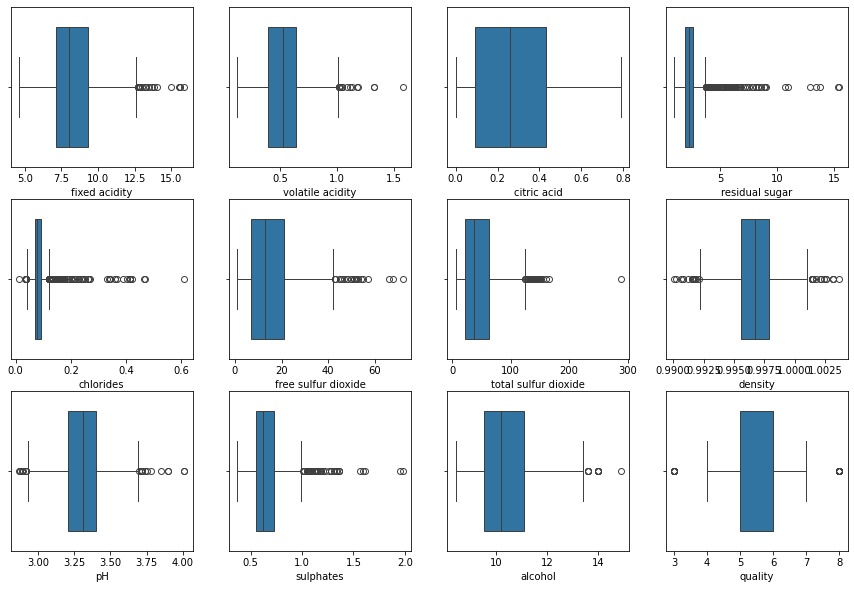

```python
# Iterate through each column and create a boxplot
plt.figure(figsize=(15, 10))
for i, column in enumerate(wein_train_cl.columns):
    plt.subplot(3, 4, i + 1)
    sns.boxplot(x=wein_train_cl[column], width=0.75)
    plt.xlabel(column)
```

## Data Exploration

Bereits in der Zusammenfassung war auffällig, dass nur Weine der Qualitätsklassen zwischen 3 und 8 im Datensatz repräsentiert sind. Ebenso sind Rotweine mittlerer Qualität (Qualität 5 und 6) überrepräsentiert. Daher werden die Qualitätsgruppen mithilfe der SMOTE ausgeglichen. Das ist für die spätere Modellierung wichtig, damit die Eigenschaften aller Qualitätsklassen gleichmäßig erlernt werden was die Vorraussetzung für eine erfolgreiche Vorhersage-Performance ist.

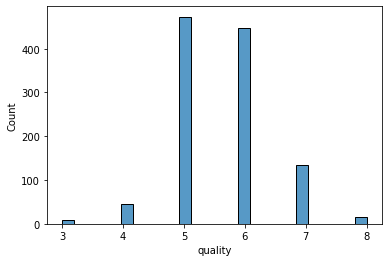

```python
sns.histplot(wein_train_cl["quality"])   # eigentlich schon im df summary
```

```python
X = wein_train_cl.drop("quality", axis=1)
y = wein_train_cl["quality"]

# 1. Resampling durchführen
smote = SMOTE()
X_resampled, y_resampled = smote.fit_resample(X, y)

# rs steht für "resampled"
wein_train_cl_rs = pd.concat([pd.DataFrame(X_resampled), pd.Series(y_resampled, name="quality")], axis=1)
```

```python
dfSummary(wein_train_cl_rs, is_collapsible = True)
```

**Data Frame Summary** wein_train_cl_rs Dimensions: 2,838 x 12 Duplicates: 0

| No | Variable | Stats / Values | Freqs / (% of Valid) | Graph | Missing |
| --- | --- | --- | --- | --- | --- |
| 1 | **fixed acidity** [float64] | Mean (sd) : 8.3 (1.7) min < med < max: 4.6 < 8.0 < 15.9 IQR (CV) : 2.2 (5.0) | 1,775 distinct values |  | 0 (0.0%) |
| 2 | **volatile acidity** [float64] | Mean (sd) : 0.6 (0.3) min < med < max: 0.1 < 0.6 < 1.6 IQR (CV) : 0.3 (2.3) | 1,837 distinct values |  | 0 (0.0%) |
| 3 | **citric acid** [float64] | Mean (sd) : 0.3 (0.2) min < med < max: 0.0 < 0.3 < 0.8 IQR (CV) : 0.4 (1.3) | 1,680 distinct values |  | 0 (0.0%) |
| 4 | **residual sugar** [float64] | Mean (sd) : 2.6 (1.2) min < med < max: 0.9 < 2.3 < 15.5 IQR (CV) : 0.9 (2.2) | 1,725 distinct values |  | 0 (0.0%) |
| 5 | **chlorides** [float64] | Mean (sd) : 0.1 (0.0) min < med < max: 0.0 < 0.1 < 0.6 IQR (CV) : 0.0 (2.1) | 1,844 distinct values |  | 0 (0.0%) |
| 6 | **free sulfur dioxide** [float64] | Mean (sd) : 13.6 (10.0) min < med < max: 1.0 < 10.9 < 72.0 IQR (CV) : 12.2 (1.4) | 1,494 distinct values |  | 0 (0.0%) |
| 7 | **total sulfur dioxide** [float64] | Mean (sd) : 37.4 (28.6) min < med < max: 6.0 < 28.0 < 289.0 IQR (CV) : 34.0 (1.3) | 1,699 distinct values |  | 0 (0.0%) |
| 8 | **density** [float64] | Mean (sd) : 1.0 (0.0) min < med < max: 1.0 < 1.0 < 1.0 IQR (CV) : 0.0 (522.6) | 2,101 distinct values |  | 0 (0.0%) |
| 9 | **pH** [float64] | Mean (sd) : 3.3 (0.2) min < med < max: 2.9 < 3.3 < 4.0 IQR (CV) : 0.2 (21.4) | 1,767 distinct values |  | 0 (0.0%) |
| 10 | **sulphates** [float64] | Mean (sd) : 0.7 (0.2) min < med < max: 0.4 < 0.6 < 2.0 IQR (CV) : 0.2 (4.4) | 1,731 distinct values |  | 0 (0.0%) |
| 11 | **alcohol** [float64] | Mean (sd) : 10.8 (1.2) min < med < max: 8.4 < 10.6 < 14.9 IQR (CV) : 1.8 (8.9) | 1,712 distinct values |  | 0 (0.0%) |
| 12 | **quality** [int64] | 1. 6 2. 5 3. 7 4. 8 5. 4 6. 3 | 473 (16.7%) 473 (16.7%) 473 (16.7%) 473 (16.7%) 473 (16.7%) 473 (16.7%) |  | 0 (0.0%) |

Korrelationen zwischen den Merkmalen geben einen ersten Eindruck wie stark und in welcher Richtung zwei Merkmale miteinander in Verbindung stehen. Dabei wurden manche Korrelationen durch das Resampling stärker ausgeprägt. Prinzipiell sollten Merkmale mit sehr positiver (>0.7) oder negativer Korrelation (<-0.7) entfernt werden, um Multikollinearität zu vermeiden.

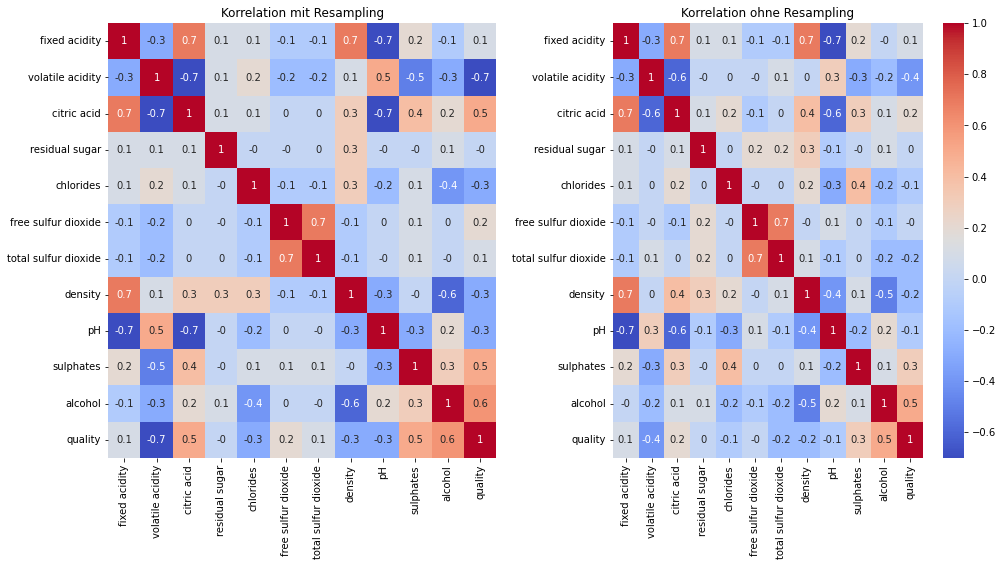

```python
correlation_rs = wein_train_cl_rs.corr()
correlation = wein_train_cl.corr()
fig, axes = plt.subplots(nrows=1, ncols=2, figsize=(16, 8))
sns.heatmap(correlation_rs.round(1), annot = True, cmap = "coolwarm", cbar = False, ax = axes[0])
axes[0].set_title("Korrelation mit Resampling")
sns.heatmap(correlation.round(1), annot = True, cmap = "coolwarm", ax = axes[1])
axes[1].set_title("Korrelation ohne Resampling")

plt.subplots_adjust(wspace=0.3)
```

```python
wein_train_cl_rs = wein_train_cl_rs.drop(["citric acid", "pH", "free sulfur dioxide"], axis=1)
```

mit der Korrelation werden lineare Zusammenhänge erfasst. Der "Mutual Information" gibt Auskunft darüber, wie gut die gemeinsame Wahrscheinlichkeitsverteilung von Qualität und einem anderen Merkmal X durch die Verteilung von X allein erklärt werden kann. Daher können auch nicht-lineare Zusammenhänge berücksichtigt werden.

```python
# Berechne die Mutual Information Scores für alle Features
X = wein_train_cl_rs.drop("quality", axis = 1)
y = wein_train_cl_rs["quality"]
mutual_info_scores = mutual_info_classif(X, y)

# Erstelle ein DataFrame, um die Features und ihre Scores anzuzeigen
mi_scores = pd.DataFrame({"Feature": X.columns, "Mutual_Information_Score": mutual_info_scores})

# Sortiere das DataFrame nach den Scores in absteigender Reihenfolge
mi_scores = mi_scores.sort_values(by="Mutual_Information_Score", ascending=False)

mi_scores
```

|  | Feature | Mutual_Information_Score |
| --- | --- | --- |
| 7 | alcohol | 0.697417 |
| 6 | sulphates | 0.642228 |
| 1 | volatile acidity | 0.605726 |
| 3 | chlorides | 0.527613 |
| 4 | total sulfur dioxide | 0.522542 |
| 0 | fixed acidity | 0.399458 |
| 2 | residual sugar | 0.373448 |
| 5 | density | 0.258975 |

Das heißt, wenn der MI-Wert hoch ist, kann durch Kenntnis der Werte von X viel über die Qualität ausgesagt werden. Daher sind die 4 einflussreichsten Faktoren für die Weinqualität: Alkoholgehalt, Sulphatgehalt, Freie Säuren, Chloridgehalt (mit absteigender Bedeutung). Um Unterschiede in diesen Merkmalen zwischen den hohen (7 und 8) und mittleren Qualitätsstufen (5 und 6) zu visualisieren, sind die Verteilungen dargestellt und Mittelwerte berechnet.

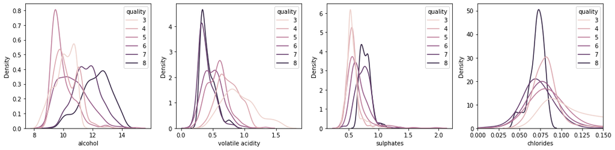

```python
selected_vars = ["alcohol", "sulphates", "volatile acidity", "chlorides"]
quality_values = [3,4,5, 6, 7, 8]

plt.figure(figsize=(18, 4))
selected_vars = ["alcohol", "volatile acidity", "sulphates"]
for i , var in enumerate(selected_vars):
    plt.subplot(1, 4, i + 1)
    sns.kdeplot(data=wein_train_cl_rs[wein_train_cl_rs["quality"].isin(quality_values)], x=var, hue="quality", common_norm=False)
    plt.xlabel(var)
plt.subplot(1, 4, 4)
sns.kdeplot(data=wein_train_cl_rs[wein_train_cl_rs["quality"].isin(quality_values)], x="chlorides", hue="quality", common_norm=False)
plt.xlim(0.0, 0.15)
plt.xlabel("chlorides")
```

```python
selected_vars = ["alcohol", "volatile acidity", "sulphates", "chlorides"]

average_values = wein_train_cl_rs.groupby("quality")[selected_vars].mean()
print(average_values)
```

```
           alcohol  volatile acidity  sulphates  chlorides
quality
3        10.046957          0.918633   0.558255   0.124402
4        10.259756          0.746817   0.568500   0.081791
5         9.905391          0.573932   0.625603   0.094275
6        10.621253          0.502652   0.676801   0.085928
7        11.601422          0.398043   0.745962   0.075628
8        12.228642          0.424666   0.780556   0.070317
```

Aus den Verteilungen und Mittelwerte lassen sich Tendenzen ableiten, die Rotweine hoher Qualität von mittlerer Qualität unterscheiden. Rotweine hoher Qualität haben tendenziell einen höheren Alkohol und Sulphat Gehalt, und eine geringeren Menge an Freier Säuren. Um diese Vermutungen zu untermauern, werden statistische Unterschiede in den Mittelwerten gesucht. Zuerst führe ich eine einfaktorielle ANOVA durch, um zu bestätigen dass mindestens der Qualitätsgruppen unterschiedliche Durchschnittswerte aufweist. Danach werden mit dem Tukey-test die Unterschiede zwischen den Qulitätsgruppen genauer aufgedeckt.

```python
def ANOVA(feature):
    f_statistic, p_value = f_oneway(wein_train_cl_rs[feature][wein_train_cl_rs["quality"] == 3],
                                    wein_train_cl_rs[feature][wein_train_cl_rs["quality"] == 4],
                                    wein_train_cl_rs[feature][wein_train_cl_rs["quality"] == 5],
                                    wein_train_cl_rs[feature][wein_train_cl_rs["quality"] == 6],
                                    wein_train_cl_rs[feature][wein_train_cl_rs["quality"] == 7],
                                    wein_train_cl_rs[feature][wein_train_cl_rs["quality"] == 8])
    if p_value < 0.05:
        print(f"Signifikante Unterschiede zwischen den Gruppen in {feature}, p-Wert = {p_value}")
    else:
        print(f"Keine signifikanten Unterschiede in {feature} gefunden.")
```

```python
for f in selected_vars:
    ANOVA(f)
```

```
Signifikante Unterschiede zwischen den Gruppen in alcohol, p-Wert = 0.0
Signifikante Unterschiede zwischen den Gruppen in volatile acidity, p-Wert = 0.0
Signifikante Unterschiede zwischen den Gruppen in sulphates, p-Wert = 1.29766839707472e-221
Signifikante Unterschiede zwischen den Gruppen in chlorides, p-Wert = 6.170707695325349e-116
```

```python
# Tukey Test für"alcohol"
tukey_alcohol = pairwise_tukeyhsd(wein_train_cl_rs["alcohol"], wein_train_cl_rs["quality"], alpha=0.05)
print(tukey_alcohol)
```

```
Multiple Comparison of Means - Tukey HSD, FWER=0.05
====================================================
group1 group2 meandiff p-adj   lower   upper  reject
----------------------------------------------------
     3      4   0.2128  0.002  0.0536   0.372   True
     3      5  -0.1416 0.1143 -0.3008  0.0177  False
     3      6   0.5743    0.0  0.4151  0.7335   True
     3      7   1.5545    0.0  1.3952  1.7137   True
     3      8   2.1817    0.0  2.0225  2.3409   True
     4      5  -0.3544    0.0 -0.5136 -0.1951   True
     4      6   0.3615    0.0  0.2023  0.5207   True
     4      7   1.3417    0.0  1.1824  1.5009   True
     4      8   1.9689    0.0  1.8097  2.1281   True
     5      6   0.7159    0.0  0.5566  0.8751   True
     5      7    1.696    0.0  1.5368  1.8553   True
     5      8   2.3233    0.0   2.164  2.4825   True
     6      7   0.9802    0.0  0.8209  1.1394   True
     6      8   1.6074    0.0  1.4482  1.7666   True
     7      8   0.6272    0.0   0.468  0.7864   True
----------------------------------------------------
```

```python
# für "volatile acidity"
tukey_va = pairwise_tukeyhsd(wein_train_cl_rs["volatile acidity"], wein_train_cl_rs["quality"], alpha=0.05)
print(tukey_va)
```

```
Multiple Comparison of Means - Tukey HSD, FWER=0.05
====================================================
group1 group2 meandiff p-adj   lower   upper  reject
----------------------------------------------------
     3      4  -0.1718    0.0  -0.204 -0.1396   True
     3      5  -0.3447    0.0 -0.3769 -0.3125   True
     3      6   -0.416    0.0 -0.4482 -0.3838   True
     3      7  -0.5206    0.0 -0.5528 -0.4884   True
     3      8   -0.494    0.0 -0.5262 -0.4618   True
     4      5  -0.1729    0.0 -0.2051 -0.1407   True
     4      6  -0.2442    0.0 -0.2764  -0.212   True
     4      7  -0.3488    0.0  -0.381 -0.3166   True
     4      8  -0.3222    0.0 -0.3544   -0.29   True
     5      6  -0.0713    0.0 -0.1035 -0.0391   True
     5      7  -0.1759    0.0 -0.2081 -0.1437   True
     5      8  -0.1493    0.0 -0.1815 -0.1171   True
     6      7  -0.1046    0.0 -0.1368 -0.0724   True
     6      8   -0.078    0.0 -0.1102 -0.0458   True
     7      8   0.0266 0.1717 -0.0056  0.0588  False
----------------------------------------------------
```

```python
# für "sulphates"
tukey_sulphates = pairwise_tukeyhsd(wein_train_cl_rs["sulphates"], wein_train_cl_rs["quality"], alpha=0.05)
print(tukey_sulphates)
```

```
Multiple Comparison of Means - Tukey HSD, FWER=0.05
===================================================
group1 group2 meandiff p-adj   lower  upper  reject
---------------------------------------------------
     3      4   0.0102 0.8131 -0.0132 0.0337  False
     3      5   0.0673    0.0  0.0439 0.0908   True
     3      6   0.1185    0.0  0.0951  0.142   True
     3      7   0.1877    0.0  0.1643 0.2111   True
     3      8   0.2223    0.0  0.1989 0.2457   True
     4      5   0.0571    0.0  0.0337 0.0805   True
     4      6   0.1083    0.0  0.0849 0.1317   True
     4      7   0.1775    0.0   0.154 0.2009   True
     4      8   0.2121    0.0  0.1886 0.2355   True
     5      6   0.0512    0.0  0.0278 0.0746   True
     5      7   0.1204    0.0  0.0969 0.1438   True
     5      8    0.155    0.0  0.1315 0.1784   True
     6      7   0.0692    0.0  0.0457 0.0926   True
     6      8   0.1038    0.0  0.0803 0.1272   True
     7      8   0.0346 0.0004  0.0112  0.058   True
---------------------------------------------------
```

```python
# "chlorides"
tukey_chlorides = pairwise_tukeyhsd(wein_train_cl_rs["chlorides"], wein_train_cl_rs["quality"], alpha=0.05)
print(tukey_chlorides)
```

```
Multiple Comparison of Means - Tukey HSD, FWER=0.05
====================================================
group1 group2 meandiff p-adj   lower   upper  reject
----------------------------------------------------
     3      4  -0.0426    0.0 -0.0497 -0.0355   True
     3      5  -0.0301    0.0 -0.0372  -0.023   True
     3      6  -0.0385    0.0 -0.0456 -0.0314   True
     3      7  -0.0488    0.0 -0.0559 -0.0417   True
     3      8  -0.0541    0.0 -0.0612  -0.047   True
     4      5   0.0125    0.0  0.0054  0.0196   True
     4      6   0.0041 0.5581  -0.003  0.0112  False
     4      7  -0.0062 0.1319 -0.0133  0.0009  False
     4      8  -0.0115 0.0001 -0.0186 -0.0044   True
     5      6  -0.0083 0.0106 -0.0154 -0.0012   True
     5      7  -0.0186    0.0 -0.0257 -0.0115   True
     5      8   -0.024    0.0 -0.0311 -0.0169   True
     6      7  -0.0103 0.0005 -0.0174 -0.0032   True
     6      8  -0.0156    0.0 -0.0227 -0.0085   True
     7      8  -0.0053  0.271 -0.0124  0.0018  False
----------------------------------------------------
```

Die Ergebnisse verdeutlichen, dass beim Alkohol, Sulphat und Gehalt Freier Säuren ein signifikanter Unterschied zwischen mittlerer und hoher Qualität zu beobachten ist. Beim Chloridgehalt ist der Unterschied weniger deutlich, jedoch sind die mittlere Chloridwerte zwischen niedriger und hoher Qualitätsstufe deutlich.

```python
# save prepared dataset
wein_train_cl_rs.to_csv("wein_train_cl_rs.csv", index=False)
wein_test.to_csv("wein_test.csv", index = False)
```